# An RMarkdown report

Your name

## Data description

In this project we consider the classical `iris` data set that can be found in the base R package `datasets`. `iris` has **5** columns named **Sepal.Length, Sepal.Width, Petal.Length, Petal.Width, Species** and **150**  
observations.

To get help about columns, run `?iris`.

The data set `iris` is

| Sepal.Length | Sepal.Width | Petal.Length | Petal.Width | Species |
| --- | --- | --- | --- | --- |
| 5.1 | 3.5 | 1.4 | 0.2 | setosa |
| 4.9 | 3.0 | 1.4 | 0.2 | setosa |
| 4.7 | 3.2 | 1.3 | 0.2 | setosa |
| 4.6 | 3.1 | 1.5 | 0.2 | setosa |
| 5.0 | 3.6 | 1.4 | 0.2 | setosa |
| 5.4 | 3.9 | 1.7 | 0.4 | setosa |
| 4.6 | 3.4 | 1.4 | 0.3 | setosa |
| 5.0 | 3.4 | 1.5 | 0.2 | setosa |
| 4.4 | 2.9 | 1.4 | 0.2 | setosa |
| 4.9 | 3.1 | 1.5 | 0.1 | setosa |

[output cut: 140 more lines]

## Descriptive analysis

First, we compute some descriptive statistics with the `summary()` function:

Descriptive statistics

|  | Sepal.Length | Sepal.Width | Petal.Length | Petal.Width | Species |
| --- | --- | --- | --- | --- | --- |
|  | Min. :4.30 | Min. :2.00 | Min. :1.00 | Min. :0.1 | setosa :50 |
|  | 1st Qu.:5.10 | 1st Qu.:2.80 | 1st Qu.:1.60 | 1st Qu.:0.3 | versicolor:50 |
|  | Median :5.80 | Median :3.00 | Median :4.35 | Median :1.3 | virginica :50 |
|  | Mean :5.84 | Mean :3.06 | Mean :3.76 | Mean :1.2 |  |
|  | 3rd Qu.:6.40 | 3rd Qu.:3.30 | 3rd Qu.:5.10 | 3rd Qu.:1.8 |  |
|  | Max. :7.90 | Max. :4.40 | Max. :6.90 | Max. :2.5 |  |

Second, we use the function `aggregate` to get the following table that shows the means of the $4$ numerical variables for each species.

Means by species

| Species | Sepal Length | Sepal Width | Petal Length | Petal Width |
| --- | --- | --- | --- | --- |
| setosa | 5.01 | 3.43 | 1.46 | 0.246 |
| versicolor | 5.94 | 2.77 | 4.26 | 1.326 |
| virginica | 6.59 | 2.97 | 5.55 | 2.026 |

## Linear regression

We use the function `cor()` to get the Pearson’s coefficients of correlation between all our numeric variables:

Pearson’s coefficients of correlation

|  | Sepal.Length | Sepal.Width | Petal.Length | Petal.Width |
| --- | --- | --- | --- | --- |
| Sepal.Length | 1.000 | -0.118 | 0.872 | 0.818 |
| Sepal.Width | -0.118 | 1.000 | -0.428 | -0.366 |
| Petal.Length | 0.872 | -0.428 | 1.000 | 0.963 |
| Petal.Width | 0.818 | -0.366 | 0.963 | 1.000 |

Here are 3 scatter plots that show the association between `Petal.Length` and the other numerical variables.

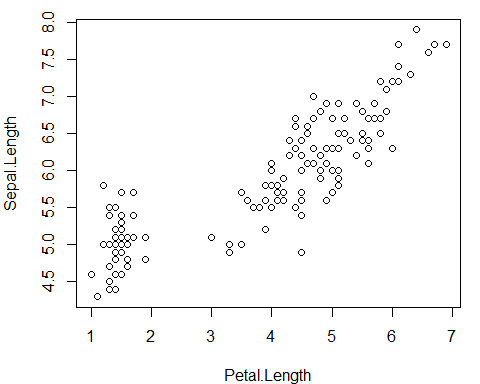

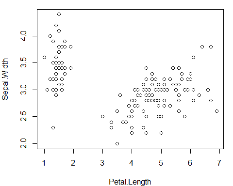

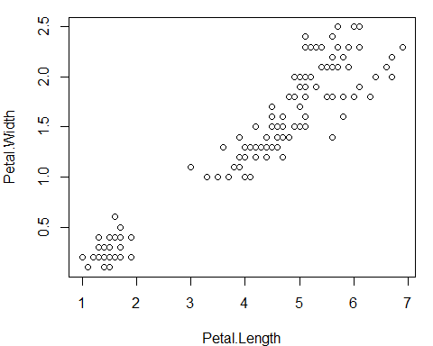

Now, we would like to explain the variations in the length of the sepal as a function of the length of the petal. To do so, we use the following linear regression `lm(Sepal.Length ~ Petal.Length, data = iris)`. Here is the summary of this model:

Summary of lm: Sepal.Length ~ Petal.Length

|  | Estimate | Std. Error | t value | Pr(>\|t\|) |
| --- | --- | --- | --- | --- |
| (Intercept) | 4.307 | 0.078 | 54.9 | 0.00e+00 |
| Petal.Length | 0.409 | 0.019 | 21.6 | 1.04e-47 |

The model’s equation is
$$\widehat{Sepal.Length} = 4.307+ 0.409 Petal.Length.$$

Here are the data with the regression line:

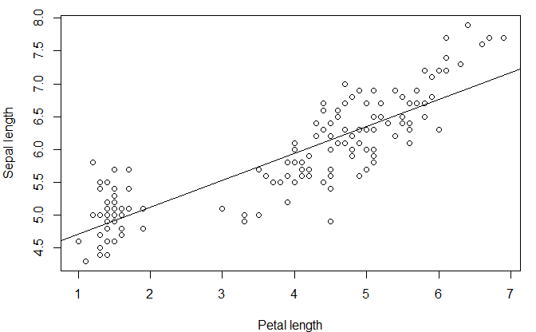

Finally, we use the `plot(reg)` command to get some graphical representations of the residuals.

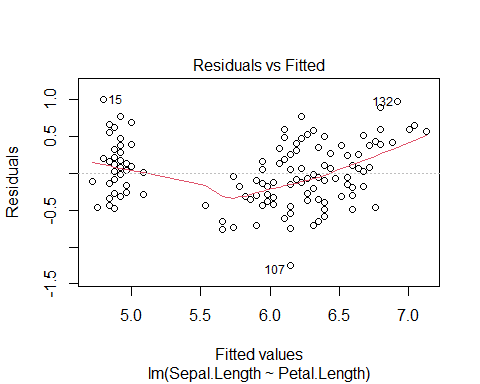

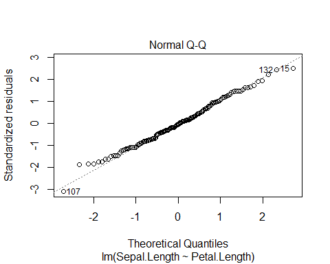

Residuals plot 1

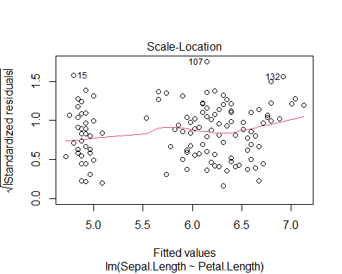

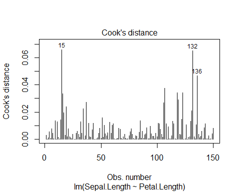

Residuals plot 2